# Test a Perceptual Phenomenon

### Analyzing the Stroop Effect

Perform the analysis in the space below. Remember to follow [the instructions](https://docs.google.com/document/d/1-OkpZLjG_kX9J6LIQ5IltsqMzVWjh36QpnP2RYpVdPU/pub?embedded=True) and review the [project rubric](https://review.udacity.com/#!/rubrics/71/view) before submitting. Once you've completed the analysis and write-up, download this file as a PDF or HTML file, upload that PDF/HTML into the workspace here (click on the orange Jupyter icon in the upper left then Upload), then use the Submit Project button at the bottom of this page. This will create a zip file containing both this .ipynb doc and the PDF/HTML doc that will be submitted for your project.

(1) What is the independent variable? What is the dependent variable?

the independent variable is the word that is shown on the desktop. the word is shown in a color. the color and the word color is mostly not the same the dependent variable is the time variable. this time changes for each user and for each word.

(2) What is an appropriate set of hypotheses for this task? Specify your null and alternative hypotheses, and clearly define any notation used. Justify your choices.

as the sample size is under 30 we cannot arrange for a z-test we must arrange for a t-test. the null hypothesis would be that the time for reading the normal words would not differ from the words that we read the changed words. the changed word are the words that differs from the color. for example the word yellow which is written in blue. H0: uc = u1 - uc are the time reading for the words that are congruently colored and u1 is the time reading the incongruently words so the alternative hypothesis is H1:uc != u1

(3) Report some descriptive statistics regarding this dataset. Include at least one measure of central tendency and at least one measure of variability. The name of the data file is 'stroopdata.csv'.

```python
# import libraries
import math
import matplotlib.pyplot as plt
import numpy as np
import pandas as pd
import seaborn as sns
from scipy.stats import t

# Perform the analysis here
#load data
df = pd.read_csv('stroopdata.csv')

#check tail and head
df.tail()
df.head()
#personal.head()
print(df)
```

```
    Congruent  Incongruent
0      12.079       19.278
1      16.791       18.741
2       9.564       21.214
3       8.630       15.687
4      14.669       22.803
5      12.238       20.878
6      14.692       24.572
7       8.987       17.394
8       9.401       20.762
9      14.480       26.282
10     22.328       24.524
11     15.298       18.644
12     15.073       17.510
13     16.929       20.330
14     18.200       35.255
15     12.130       22.158
16     18.495       25.139
17     10.639       20.429
18     11.344       17.425
19     12.369       34.288
20     12.944       23.894
21     14.233       17.960
22     19.710       22.058
23     16.004       21.157
```

(4) Provide one or two visualizations that show the distribution of the sample data. Write one or two sentences noting what you observe about the plot or plots.

```
Text(0,0.5,'how often we got this value')
```

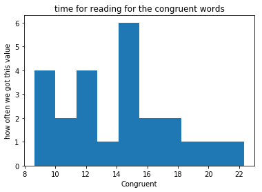

```python
# one visualations for the congruent data
plt.hist(df["Congruent"])
plt.title("time for reading for the congruent words")
plt.xlabel ("Congruent")
plt.ylabel("how often we got this value")
```

```python
df.describe()
```

|  | Congruent | Incongruent |
| --- | --- | --- |
| count | 24.000000 | 24.000000 |
| mean | 14.051125 | 22.015917 |
| std | 3.559358 | 4.797057 |
| min | 8.630000 | 15.687000 |
| 25% | 11.895250 | 18.716750 |
| 50% | 14.356500 | 21.017500 |
| 75% | 16.200750 | 24.051500 |
| max | 22.328000 | 35.255000 |

```
Text(0,0.5,'how often we got this value')
```

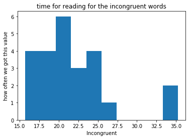

```python
#histogramm for the incongruent words
plt.hist(df["Incongruent"])
plt.title("time for reading for the incongruent words")
plt.xlabel ("Incongruent")
plt.ylabel("how often we got this value")
```

we can see that the plot differ a lot. the time on the xlabel are different. looks like the reading of the incongruent words took a lot more time.

(5) Now, perform the statistical test and report your results. What is your confidence level or Type I error associated with your test? What is your conclusion regarding the hypotheses you set up? Did the results match up with your expectations? **Hint:** Think about what is being measured on each individual, and what statistic best captures how an individual reacts in each environment.

```python
#calculate the critical value. the alphavalue shall be 0.05 and the degree of freedom per n is 23
t.ppf(0.95, 23)
```

```
1.7138715277470473
```

```python
# we calulate the differnce of mean
df.mean()
```

[output not shown]

```python
## calculate the mean difference
df['diff'] = df['Incongruent'] - df['Congruent']
df["diff"].mean()
df["diff"].std(axis = 0)
```

```
4.8648269103590556
```

```python
# so the t-test is
# difference of mean / (standard deviation / mathsqrt(n) and n is 24
df.mean()/ (df["diff"].std(axis = 0)/math.sqrt(24))
```

```
Congruent      14.149768
Incongruent    22.170475
diff            8.020707
dtype: float64
```

```python
resources:
https://brandalyzer.blog/2010/12/05/difference-between-z-test-f-test-and-t-test/
https://towardsdatascience.com/inferential-statistics-series-t-test-using-numpy-2718f8f9bf2f
https://statistics.laerd.com/statistical-guides/dependent-t-test-statistical-guide.php
https://stackoverflow.com/questions/19339305/python-function-to-get-the-t-statistic
```